# Project2

# Exploration of Crime Statistics, SAT Data, and Teen Pregnancy (and other social information) Rates by State

## SDS 322E

## Rohit Prasad (rkp679), Joonmo Chun (jcc5922), Ashlynn Barrera (anb4329)

### Introduction

We have compiled three datasets from https://vincentarelbundock.github.io/ and compiled them into a csvnfile. Specifically, we used SAT (a collection of data showcasing the relationship between SAT scores and educational expenditures), TeenPregnancy (a collection of data showcasing state teen pregnancy rates and social factors), and USArrests (a collection of data showcasing arrests per 100,000 residents for assault, murder, and rape in the US in 1973).

Similar to our first report, we chose these datasets due to them each having a common variable, “state.” From here, we wanted to explore the relationships that exist between SAT scores and social factors, including crime rates and teen pregnancy rates. In particular, we hypothesized that if possible relationships do in fact persist across differing variables, then necessary future policymaking on public education could be reformed to be more equitable and fair. Here, we hypothesize that the greater the spending is on public education, the lower the crime rates and teen pregnancy would be for that respective state. This relationship is expected, for more comprehensive education may discourage petty crimes, poor behavior, and teen pregnancies from happening. We also expect a state’s membership in the Union or Confederacy during the Civil War to be correlated with modern-day measures of social spending, particularly on education.

To begin, we full-joined the SAT dataset with the TeenPregnancy dataset and created a new version of collective data. Next, we full-joined the newly-created SAT dataset + TeenPregnancy dataset with the USArrests dataset to create ‘totalData’ dataset. Now, grouped across a similar ID variable, state name, we observed no odd data points in need of addition or deletion and continued tidying and experimenting on.

### Exploratory Data Analysis

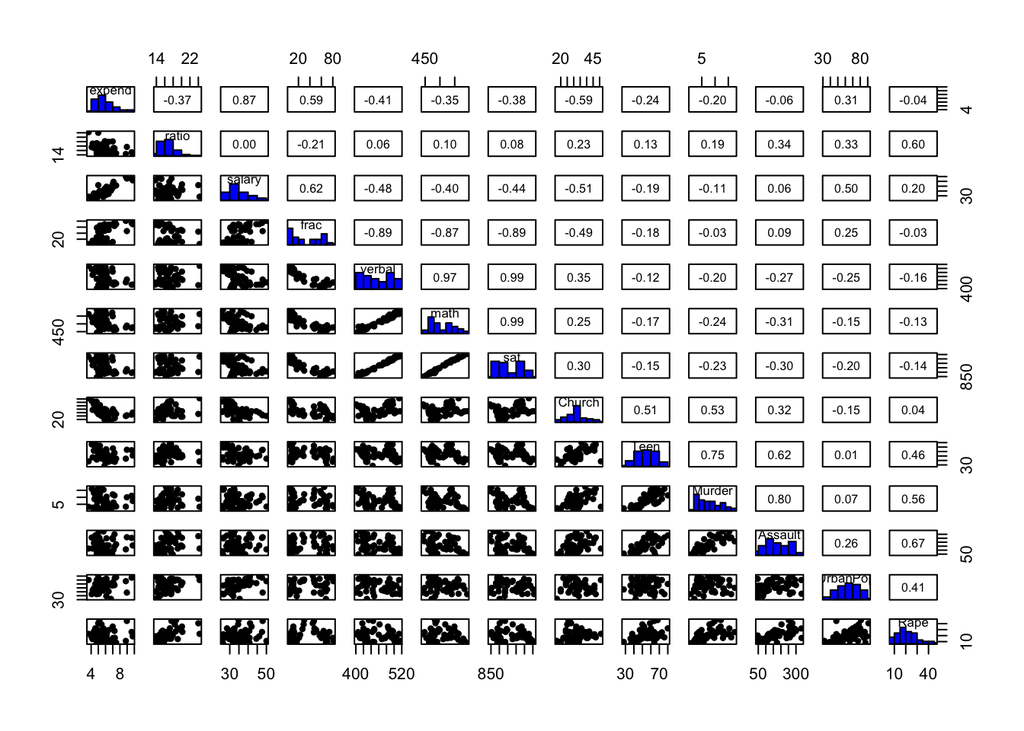

```r
# Generate univariate and bivariate graphs with correlation matrix
pairs.panels(totalData_num,
             method = "pearson", # correlation coefficient method
             hist.col = "blue", # color of histogram
             smooth = FALSE, density = FALSE, ellipses = FALSE)
```

We created a correlation matrix and found that the pairs of variables that are most closely correlated to one another are verbal SAT score to overall SAT score, and math SAT score to overall SAT score, both having a correlation coefficient of 0.99. On the other hand, the pair of variables that are least correlated to each other are the average estimated salary for teachers in each state and the student-teacher ratio of public schools in each state, which have a correlation coefficient of 0.00. Now, some trends that are apparent include high correlations between the percentage of all eligible students taking the SAT with both verbal SAT scores and the estimated average salary of teachers by state, as well as high correlations between the verbal and math SAT scores.

### PAM Clustering of Variables

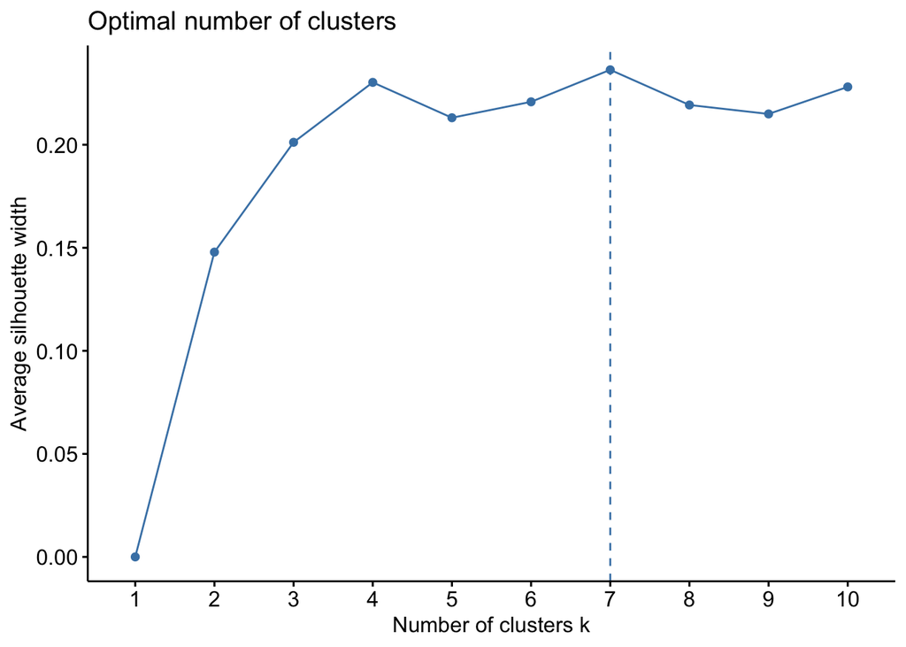

```r
# Prepare data (select variables, scale them)
totalData4 <- totalData %>%
  select(-c(State, CivilWar, satPart)) %>%
  scale

# Use Silhouette to identify best number of clusters
fviz_nbclust(totalData4, pam, method = "silhouette")
```

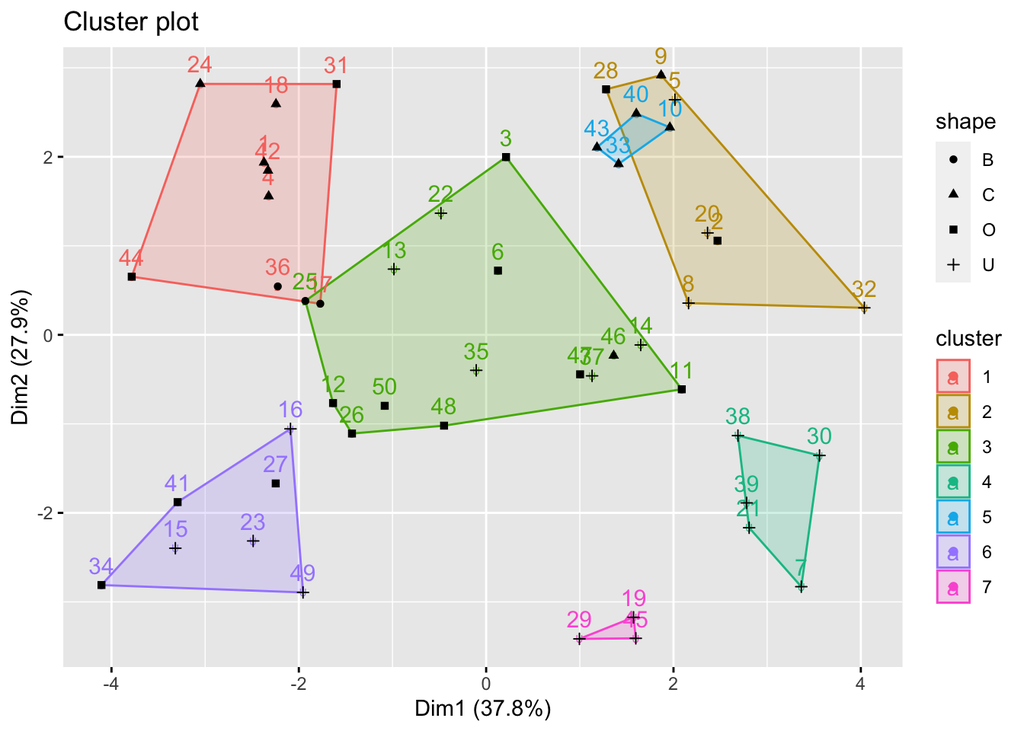

```r
# Apply a clustering algorithm using the optimal cluster number
pam_results <- totalData4 %>%
  pam(k = 7)

# Save cluster assignment as a column in your dataset
totalData_pam <- totalData %>%
  mutate(cluster = as.factor(pam_results$clustering))

# Visualize the clusters after dimension reduction
fviz_cluster(pam_results, data = totalData,
             shape = totalData$CivilWar) +
  geom_point(aes(shape = totalData$CivilWar)) +
  guides(shape = guide_legend(title = "shape"))
```

```r
# Finding means of each variable for each cluster
totalData_pam %>%
  group_by(cluster) %>%
  summarize_if(is.numeric, mean, na.rm = T)
```

```
## # A tibble: 7 × 14
##   cluster expend ratio salary  frac verbal  math   sat Church  Teen Murder
##   <fct>    <dbl> <dbl>  <dbl> <dbl>  <dbl> <dbl> <dbl>  <dbl> <dbl>  <dbl>
## 1 1         4.49  17.9   29.3  8.22   491.  537. 1028.   43.7  65.7  10.8
## 2 2         6.96  18.3   40.5 53.7    428.  478   906.   29.4  62.6  10.7
## 3 3         5.78  17.5   34.8 30.3    456.  510.  966.   30.3  53.9   7.05
## 4 4         8.09  15.0   44.4 74.2    425   471.  896.   27.4  45     4.96
## 5 5         5.07  16.2   31.1 57.5    409.  455.  864    40    65.2  14.4
## 6 6         5.67  15.5   31.9  7.29   506.  572. 1077.   31.9  43.4   3.2
## 7 7         6.35  14.4   34.0 68.7    433.  477.  911.   19    35.7   2.13
## # … with 3 more variables: Assault <dbl>, UrbanPop <dbl>, Rape <dbl>
```

```r
# Statistics for categorical variables: proportions in each cluster
prop.table(table(totalData_pam$cluster, totalData_pam$CivilWar), margin = 1)
```

```
##
##              B          C          O          U
##   1 0.22222222 0.55555556 0.22222222 0.00000000
##   2 0.00000000 0.14285714 0.28571429 0.57142857
##   3 0.06666667 0.06666667 0.53333333 0.33333333
##   4 0.00000000 0.00000000 0.00000000 1.00000000
##   5 0.00000000 1.00000000 0.00000000 0.00000000
##   6 0.00000000 0.00000000 0.42857143 0.57142857
##   7 0.00000000 0.00000000 0.00000000 1.00000000
```

```r
# Statistics for categorical variables: proportions of each civil war group
prop.table(table(totalData_pam$cluster, totalData_pam$CivilWar), margin = 2)
```

```
##
##              B          C          O          U
##   1 0.66666667 0.45454545 0.13333333 0.00000000
##   2 0.00000000 0.09090909 0.13333333 0.19047619
##   3 0.33333333 0.09090909 0.53333333 0.23809524
##   4 0.00000000 0.00000000 0.00000000 0.23809524
##   5 0.00000000 0.36363636 0.00000000 0.00000000
##   6 0.00000000 0.00000000 0.20000000 0.19047619
##   7 0.00000000 0.00000000 0.00000000 0.14285714
```

```r
# Look at final medoids
totalData[pam_results$id.med,]
```

```
##             State expend ratio salary frac verbal math  sat CivilWar Church
## 1         Alabama  4.405  17.2 31.144    8    491  538 1029        C     46
## 20       Maryland  7.245  17.0 40.661   64    430  479  909        U     31
## 35           Ohio  6.162  16.6 36.802   23    460  515  975        U     32
## 39   Rhode Island  7.469  14.7 40.729   70    425  463  888        U     28
## 40 South Carolina  4.797  16.4 30.279   58    401  443  844        C     42
## 15           Iowa  5.483  15.8 31.511    5    516  583 1099        U     32
## 19          Maine  6.428  13.8 31.972   68    427  469  896        U     20
##    Teen Murder Assault UrbanPop Rape  satPart
## 1    62   13.2     236       58 21.2 Minority
## 20   57   11.3     300       67 27.8 Majority
## 35   54    7.3     120       75 21.4 Minority
## 39   44    3.4     174       87  8.3 Majority
## 40   65   14.4     279       48 22.5 Majority
## 15   44    2.2      56       57 11.3 Minority
## 19   37    2.1      83       51  7.8 Majority
```

We first prepped our dataset in order to perform PAM on our ‘totalData’ dataset. From here, we utilized a clustering algorithm (based on silhouette width) in order to identify the ideal amount of clusters to utilize, which in our case was 7. Next, we saved the cluster assignment as a column in our dataset and then visualized our 7 clusters. After visualizing in a 2-dimension plot with the fviz_cluster function, it appeared that dimension 2 explained the greatest variance across states which were part of the confederacy versus the union in the civil war.

Calculating the statistics for Civil War status provided information on the relationship between that status and membership in a certain cluster. For example, we found that the proportion of states in the first cluster was 0.22 border states, 0.55 confederate states, 0.22 other states, and 0.00 union states. Next, we assessed the proportion of each civil war group against the clusters; for example, we found that border states distributed 0.66 proportionally in cluster 1 and 0.33 proportionally in cluster 3.

The medoids, or the observation at the center, was calculated for each cluster. Those observations were Alabama (Cluster 1), Maryland (Cluster 2), Ohio (Cluster 3), Rhode Island (Cluster 4), South Carolina (Cluster 5), Iowa (Cluster 6), and Maine (Cluster 7).

### Dimensionality Reduction

```r
# Prepare the dataset
totalData <- totalData %>%
  select(is.numeric) %>%
  # Scale the variables
  scale %>%
  as.data.frame
head(totalData)
```

```
##       expend     ratio      salary       frac     verbal       math        sat
## 1 -1.1008606 0.1509031 -0.62022479 -1.0178453  0.9625895  0.7267802  0.8430838
## 2  2.2437080 0.3273980  2.20863394  0.4394222 -0.3451222 -0.4919820 -0.4266207
## 3 -0.8271607 1.0775013 -0.44669273 -0.3078945 -0.2598366 -0.3178731 -0.2929676
## 4 -1.0612365 0.1067794 -0.99219944 -1.0925770  0.7067329  0.3536898  0.5223163
## 5 -0.6701318 3.1513162  1.05180963  0.3646905 -1.1411206 -0.5914728 -0.8543107
## 6 -0.3391971 0.6803878 -0.04341163 -0.2331628  0.1381626  0.2293263  0.1881836
##        Church       Teen     Murder   Assault   UrbanPop         Rape
## 1  1.78479990  0.6259464 1.24256408 0.7828393 -0.5209066 -0.003416473
## 2 -0.88306243  0.7974385 0.50786248 1.1068225 -1.2117642  2.484202941
## 3  0.05068938  0.4544542 0.07163341 1.4788032  0.9989801  1.042878388
## 4  1.65140678  1.5691532 0.23234938 0.2308680 -1.0735927 -0.184916602
## 5 -0.61627620  0.3687081 0.27826823 1.2628144  1.7589234  2.067820292
## 6 -1.01645555 -0.4030066 0.02571456 0.3988593  0.8608085  1.864967207
```

```r
# Compare to PCA performed with the function prcomp()
pca <- totalData %>%
  prcomp()

# Look at percentage of variance explained for each PC in a table
get_eigenvalue(pca)
```

```
##          eigenvalue variance.percent cumulative.variance.percent
## Dim.1  4.912859e+00     3.779122e+01                    37.79122
## Dim.2  3.624838e+00     2.788337e+01                    65.67459
## Dim.3  1.787098e+00     1.374691e+01                    79.42149
## Dim.4  9.850510e-01     7.577315e+00                    86.99881
## Dim.5  5.818320e-01     4.475631e+00                    91.47444
## Dim.6  3.970567e-01     3.054282e+00                    94.52872
## Dim.7  3.252639e-01     2.502030e+00                    97.03075
## Dim.8  1.711046e-01     1.316189e+00                    98.34694
## Dim.9  9.648709e-02     7.422084e-01                    99.08915
## Dim.10 5.831594e-02     4.485842e-01                    99.53773
## Dim.11 4.307150e-02     3.313193e-01                    99.86905
## Dim.12 1.702298e-02     1.309460e-01                   100.00000
## Dim.13 5.626381e-32     4.327985e-31                   100.00000
```

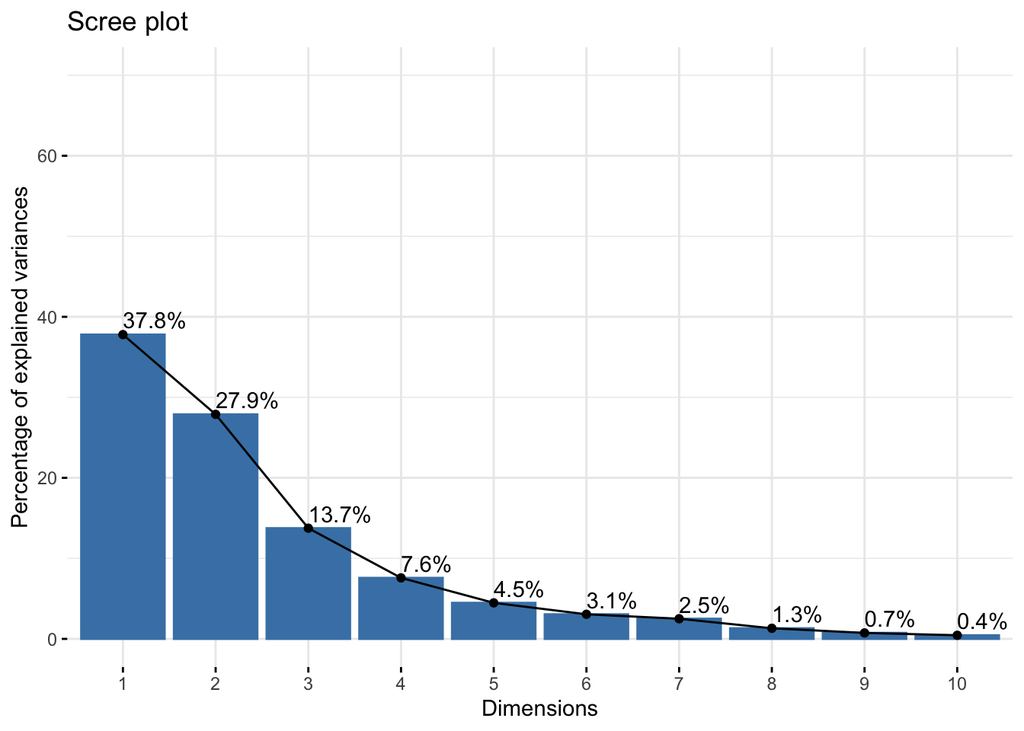

```r
# Visualize percentage of variance explained for each PC in a scree plot
fviz_eig(pca, addlabels = TRUE, ylim = c(0, 70))
```

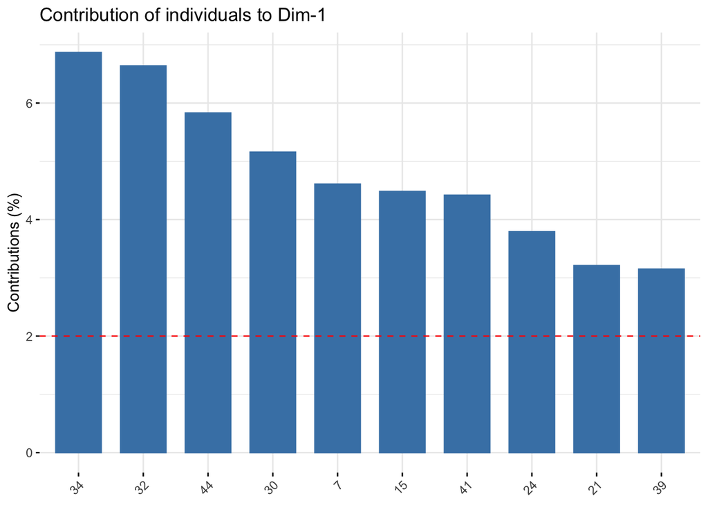

```r
# Visualize 10 top contributions to PCs
fviz_contrib(pca, choice = "ind", axes = 1, top = 10)
```

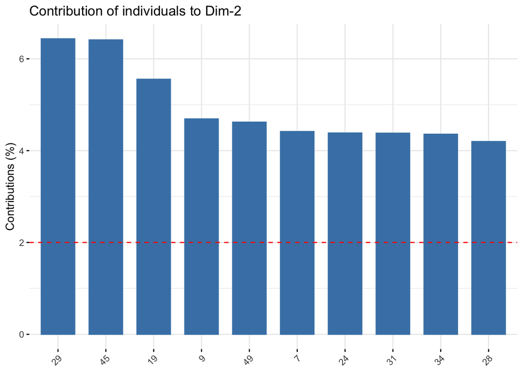

```r
fviz_contrib(pca, choice = "ind", axes = 2, top = 10)
```

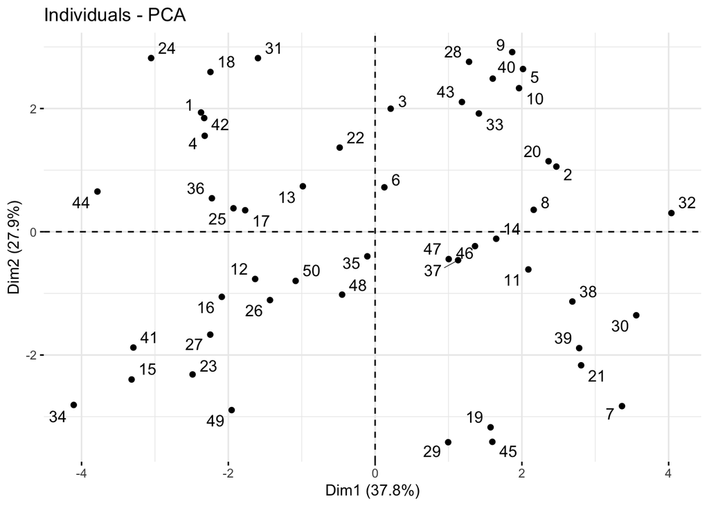

```r
# Visualize the individuals according to PC1 and PC2
fviz_pca_ind(pca, repel = TRUE) # Avoid text overlapping
```

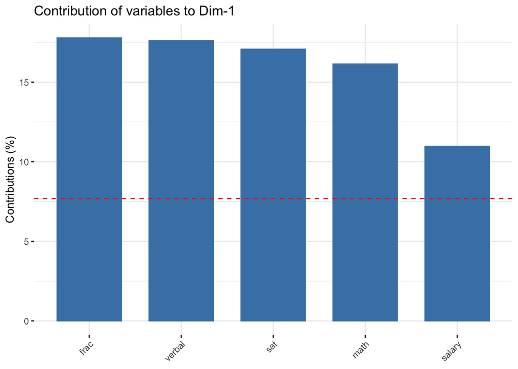

```r
# Visualize the 5 top contributions of the variables to the PCs as a percentage
  # Note the red dash line indicates the average contribution
fviz_contrib(pca, choice = "var", axes = 1, top = 5) # on PC1
```

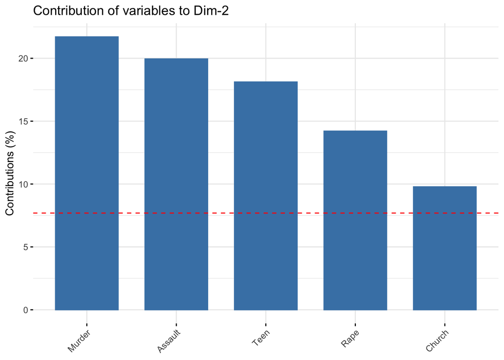

```r
fviz_contrib(pca, choice = "var", axes = 2, top = 5) # on PC2
```

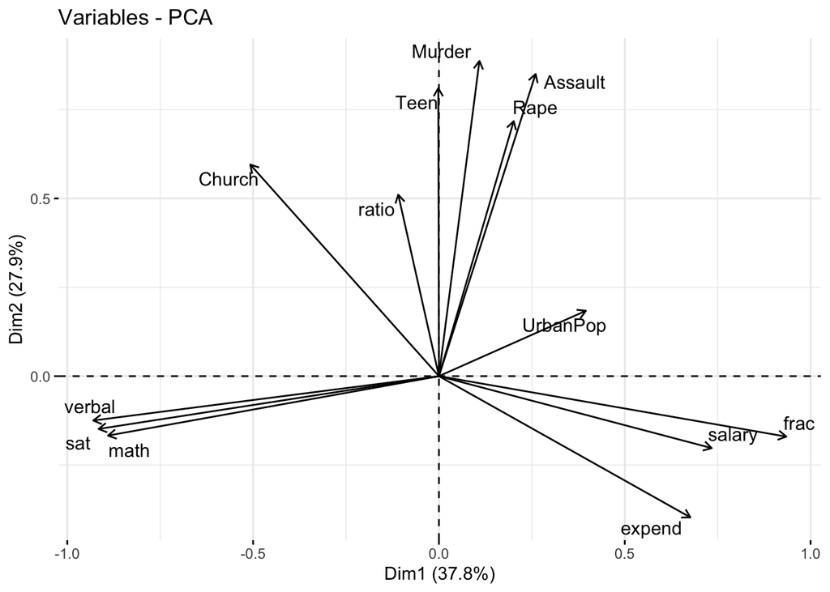

```r
# Visualize the contributions of the variables to the PCs in a correlation circle
fviz_pca_var(pca, col.var = "black", repel = TRUE) # Avoid text overlapping
```

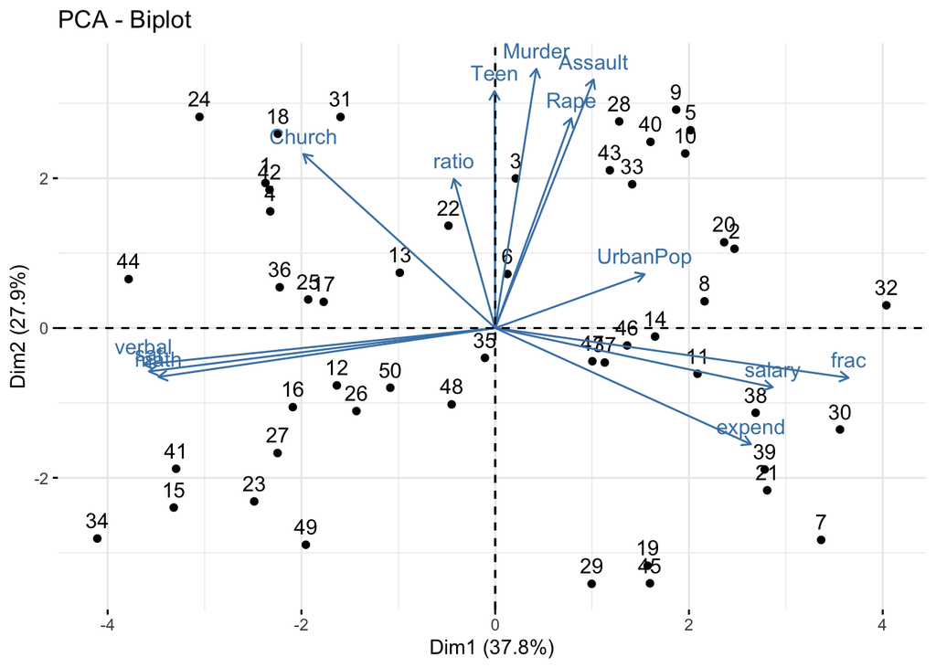

```r
# Visualize both variables and individuals in the same graph
fviz_pca_biplot(pca)
```

We found that for PC1, the variable ‘frac’ contributed the most to variance explained by that PC and for PC2, the variable ‘Murder’ contributed the most to variance explained. Following that, we visualized the contributions of each variable to the PCs’ in a correlation circle graph. Finally, the variables and individuals were visualized in the same graph.

### Classification and Cross-Validation

```r
# Subset data to only include Confederate and Union States
totalDataClassification <- totalDataClassification %>%
  filter(CivilWar == "C" | CivilWar == "U") %>%
  mutate(CivilWar = recode(CivilWar, "C" = "0", "U" = "1")) %>%
  mutate_if(is.numeric, scale) %>%
  mutate_at("CivilWar", as.numeric)

# Fit the logistic regression model to the data
fit <- glm(CivilWar ~  expend, data = totalDataClassification, family = "binomial")
summary(fit)
```

```
##
## Call:
## glm(formula = CivilWar ~ expend, family = "binomial", data = totalDataClassification)
##
## Deviance Residuals:
##      Min        1Q    Median        3Q       Max
## -1.74281  -0.13420   0.02128   0.17616   2.09199
##
## Coefficients:
##             Estimate Std. Error z value Pr(>|z|)
## (Intercept)    3.374      1.524   2.213   0.0269 *
## expend         6.561      2.649   2.477   0.0133 *
## ---
## Signif. codes:  0 '***' 0.001 '**' 0.01 '*' 0.05 '.' 0.1 ' ' 1
##
## (Dispersion parameter for binomial family taken to be 1)
##
##     Null deviance: 41.183  on 31  degrees of freedom
## Residual deviance: 12.575  on 30  degrees of freedom
## AIC: 16.575
##
## Number of Fisher Scoring iterations: 8
```

```r
# Calculate a predicted probability
log_totalData <- totalDataClassification %>%
  mutate(probability = predict(fit, type = "response"),
         predicted = ifelse(probability > 0.5, 1, 0)) %>%
  # Give a name to the rows
  rownames_to_column("state") %>%
  select(State, sat, Teen, CivilWar, probability, predicted)
head(log_totalData)
```

```
##         State        sat       Teen CivilWar probability predicted
## 1     Alabama  1.0209461  0.6739578        0 0.008404981         0
## 2    Arkansas  0.7123720  1.5863930        0 0.010750450         0
## 3  California -0.6119248  0.4251119        1 0.112116779         0
## 4 Connecticut -0.5347813 -0.8191180        1 0.999999820         1
## 5    Delaware -0.6762110  1.0887011        1 0.999330923         1
## 6     Florida -0.7790690  0.5080605        0 0.781003935         1
```

```r
# Confusion matrix: compare true to predicted condition
table(log_totalData$CivilWar, log_totalData$predicted)
```

```
##
##      0  1
##   0 10  1
##   1  1 20
```

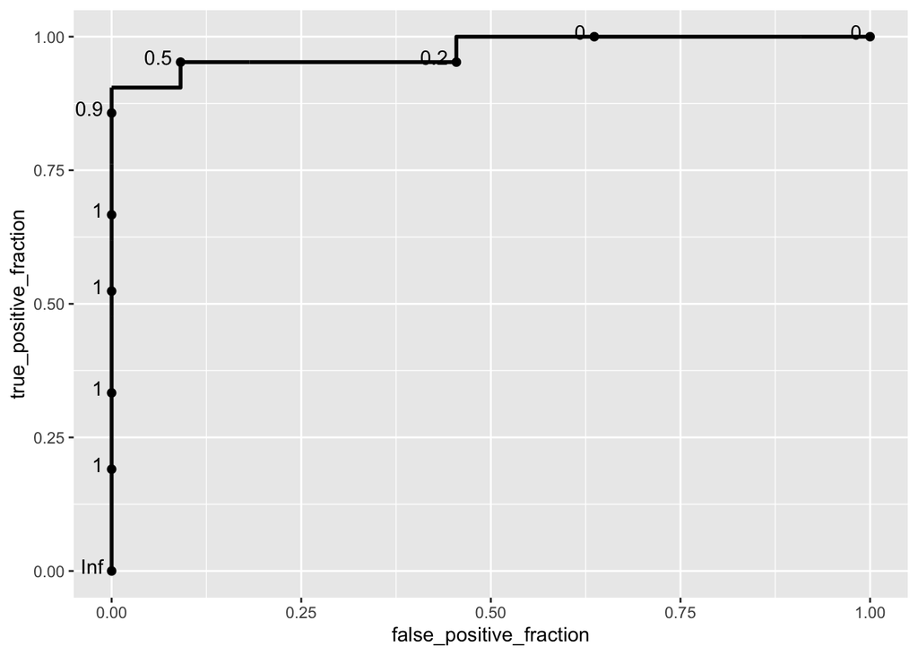

```r
# ROC curve
ROC <- ggplot(log_totalData) +
  geom_roc(aes(d = CivilWar, m = probability))
ROC
```

```r
# Calculate the area under the curve
calc_auc(ROC)
```

```
##   PANEL group      AUC
## 1     1    -1 0.974026
```

```r
##### LOOCV

tests <- data.frame()

for(i in 1:nrow(totalDataClassification)){
  # Create training and test sets
  train <- totalDataClassification[-i, ] # all observations but i
  test <- totalDataClassification[i, ]   # observation i

  # Train model on training set (all but fold i)
  fit <- glm(CivilWar ~  expend, data = train, family = "binomial")

  # Compare predicted probability to the truth
  tests <- rbind(tests, c(predict(fit, newdata = test, type = "response"),
                          CivilWar = test$CivilWar))
  names(tests) <- c("probability","CivilWar")
}

# Consider the ROC curve for the results on the test datasets
ROC <- ggplot(tests) + geom_roc(aes(d = CivilWar, m = probability))

# Get diagnostics for fold i (AUC)
diags_LOOCV <- calc_auc(ROC)$AUC

# Resulting diagnostics for average performance
diags_LOOCV
```

```
## [1] 0.9437229
```

### Contributions

All members contributed equally to the analysis and description of the results.